# qSIP_analysis

Pranav_Sampara

02/07/2020

# Introduction

qSIP analysis using sequins, MAG coverage, and MAG taxonomy is performed using this R markdown. Briefly, coverages are normalized, MAG coverages are then scaled based on linear regression models from sequin coverage and concentrations, a phyloseq object is created from MAG absolute concentrations and taxonomy (GTDB taxonomy output format is required) data. Note: Sequins that were spiked in the DNA-SIP fractions will be used in scaling and creating linear regression models for evaluating absolute MAG concentrations. Please see `sequin_scaling.R` For normalizing coverage values please see `pooling_funs.R`

This R markdown primarily uses `Tidyverse`, `phyloseq`, and `HTSSIP` packages This markdown uses functions from `functions_qSIP_MAGs.R`

## Load required data

The following files are required:

#MAG coverage data -Pooled coverages data as a comma separated file (.csv file) across samples for `Features` incuding sequins that were used as spike-ins. The followings columns are required:

-Feature: A character string describing the `Feature` label

-Sample: The label for these n number of columns should be in the format of “‘isotope’_rep_#_fraction_#”. For instance, “12C_rep_1_fraction_1”. The number of sample columns should be the same as the product of (replicates, fractions, isotopes)

#Sequin metadata -Load the sequins metadata as a comma separated file (.csv file) which has the following columns:

-Feature: As described above

-Length: Length of the sequin in bp

-GC_content: GC content of the sequin

-Sequence: Sequin nucleotide sequence

-Concentration: Concentration of the sequin in attamoles/uL

#Dilutions data -Load dilutions data as a comma separated file (.csv file) that contains the following columns:

-Sample: Similar to the sample name as described above

-Dilution: Dilution of sequins added to the fraction before sequencing.

#Fractions metadata -A fractions file as a comma separated file (.csv file) with the following columns:

-Replicate: Depends on how many replicates the study has

-Fractions: Typically in the range of 1-24

-Buoyant_density: As calculated from the refractometer for each fraction and replicate

-Isotope - “12C”, “13C”, “14N”, “15N” etc.

-DNA_concentration

-Sample - In the format “‘isotope’_rep_#_fraction_#”. For instance 12C_rep_1_fraction_1

#GTDB style taxonomy data - A taxonomy file in the GTDB output format (.tsv format). Load the bacteria and archaea taxonomy outputs separately. The markdown requires loading the standard output files from GTDB-Tk separately for bacteria and archaea

#MAG absolute concentrations -MAG absolute concentrations obtained from scaling_sequins.R. `mag_tab` object obtained from the above script is to be used as the input here

#GC content -GC content of the MAGs as a comma separated file (.csv file). The table should contain the following columns:

-OTU: MAG identifier such as the `Feature` label from the `sequin_scaling.R` script

-GC_content: GC content of the `Feature` in the range of 0-1

#Log scale BOOLEAN:

True or False depending on how you would want the MAG coverages to be scaled. Select TRUE if you need MAG concentrations scaled on the log scale

#coe_of_variation: Acceptable coeffi cient of variation for coverage and detection (eg. 20 for 20 % threshold of coefficient of variation) Coverages above the threshold value will be flagged in the plots

##Optional analysis: #Mean coverage or median coverage of features in a bin To obtain a mean or median statistic of coverage of features in a bin, please load the following data in .csv format containing the corresponding columns:

- MAG coverage data file that is previously loaded

Bins data with the following columns: - Feature: Column containing feature IDs as in the Coverage data - Bins: Bin IDs the above features belong to

Finally, provide an operator for required statistic: For mean of coverage values per bin (OR) - opr = “mean” For median of coverage values per bin - opr = “median”

#qSIP analysis

Create required `phyloseq` objects

Calculate atom fraction excess. By bootstrapping confidence intervals, determine incorporators

```
## # A tibble: 6 x 11
##   OTU    Wlab Wlight       Z    Gi Mlight Mheavymax  Mlab      A A_CI_low
##   <chr> <dbl>  <dbl>   <dbl> <dbl>  <dbl>     <dbl> <dbl>  <dbl>    <dbl>
## 1 Bin_~  1.72   1.71 0.00507 0.546   308.      318.  309. 0.0930 -0.114
## 2 Bin_~  1.71   1.70 0.00545 0.444   308.      318.  309. 0.100  -0.0279
## 3 Bin_~  1.74   1.72 0.0158  0.604   308.      318.  311. 0.289   0.0109
## 4 Bin_~  1.70   1.70 0.00472 0.382   308.      318.  309. 0.0867 -0.00570
## 5 Bin_~  1.71   1.69 0.0177  0.285   308.      318.  311. 0.323   0.0854
## 6 Bin_~  1.72   1.71 0.00613 0.541   308.      318.  309. 0.112  -0.0840
## # ... with 1 more variable: A_CI_high <dbl>
```

```
## Number of incorporators: 9
```

```
## Incorporators:
```

```
## # A tibble: 9 x 2
##   OTU              Taxonomy
##   <fct>            <chr>
## 1 Bin_1-contigs    s__Echinicola vietnamensis
## 2 Bin_12-contigs   s__Frateuria aurantia
## 3 Bin_14-contigs   s__Pseudomonas_A stutzeri_AE
## 4 Bin_17_1-contigs s__Hirschia baltica
## 5 Bin_17_2-contigs s__Streptococcus pyogenes
## 6 Bin_19-contigs   s__Coraliomargarita akajimensis
## 7 Bin_7_1-contigs  s__Desulfosporosinus meridiei
## 8 Bin_7_2-contigs  s__Terriglobus roseus
## 9 Bin_8-contigs    s__Desulfosporosinus acidiphilus
```

Plot the atom fraction excess plot

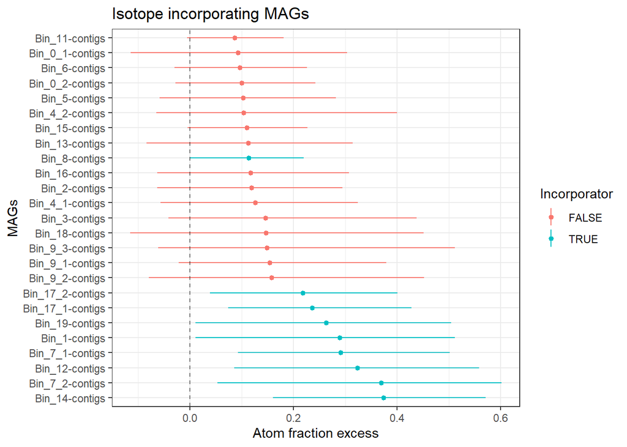

## Optional workflow to view abundance vs BD plots of incorporators

This is an optional workflow that outputs plots with mean and standard deviation of abundance and mean buoyant density across the replicates for the incorporators. The plots are saved in the folder “abundance_plots” in the current directory

#Input parameters - incorporator_list - A tibble of incorporators and their taxonomy as obtained from the previous steps of the markdown

- fractions - The same fractions metadata file as loaded previously
- mag_tab - MAG abundance estimates calculated from the `sequin_scaling.R` function in this markdown

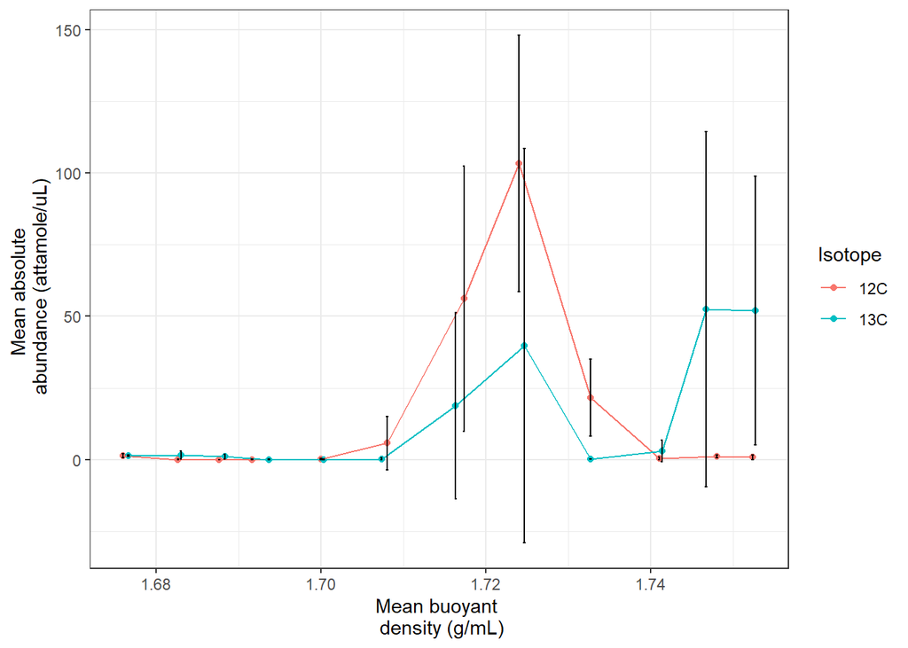

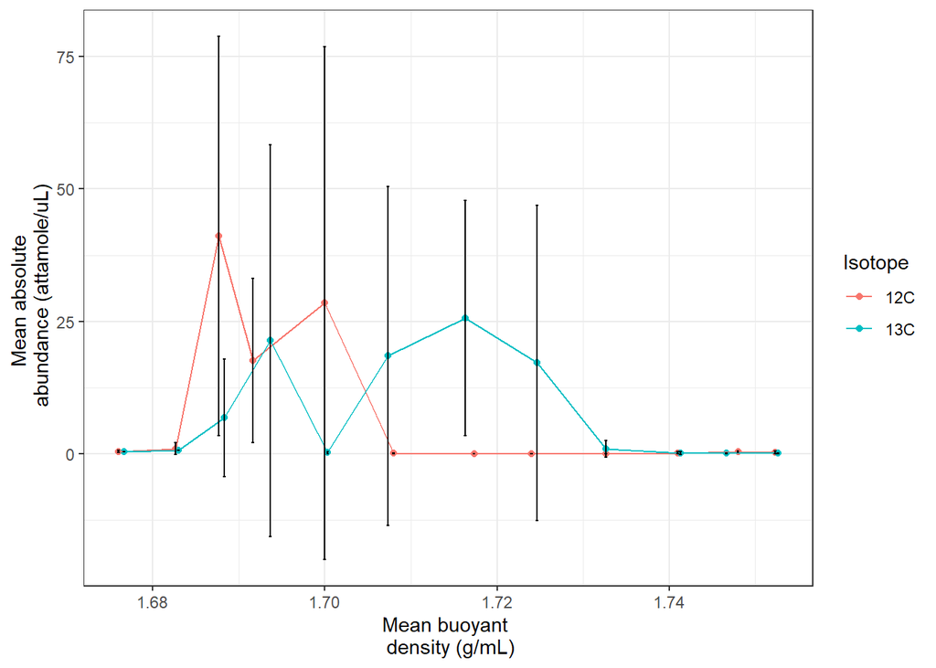

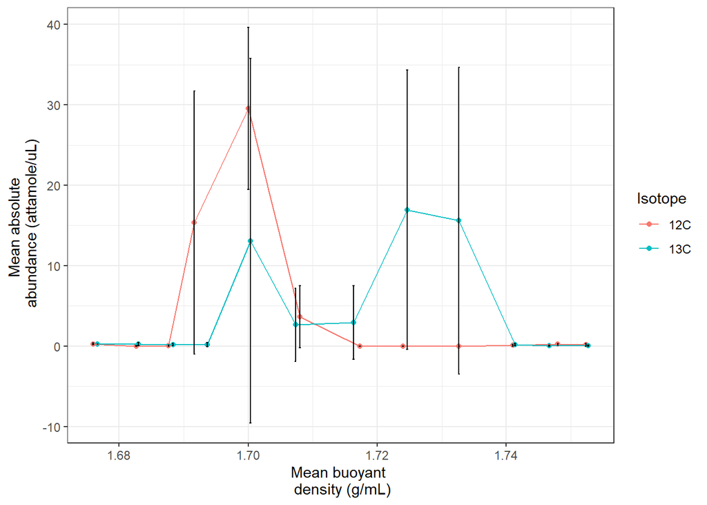

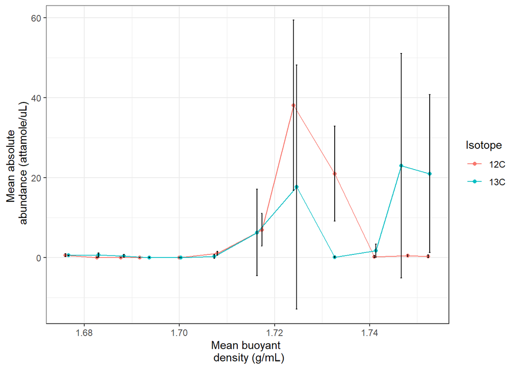

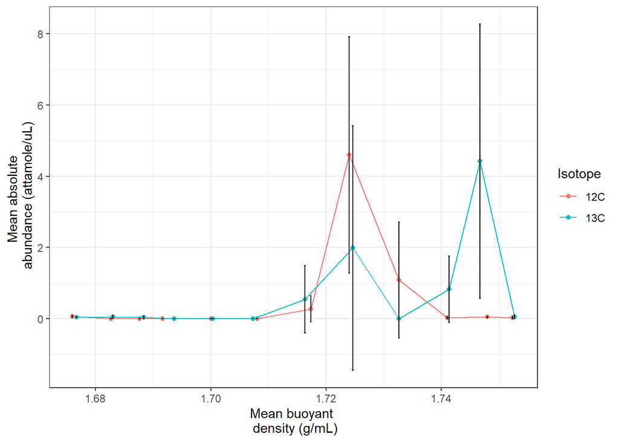

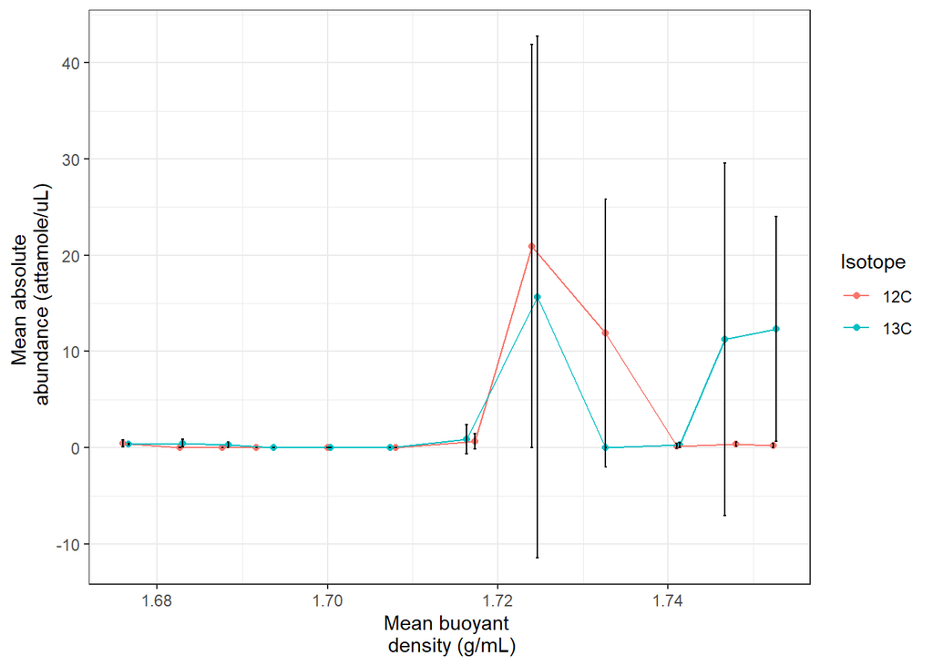

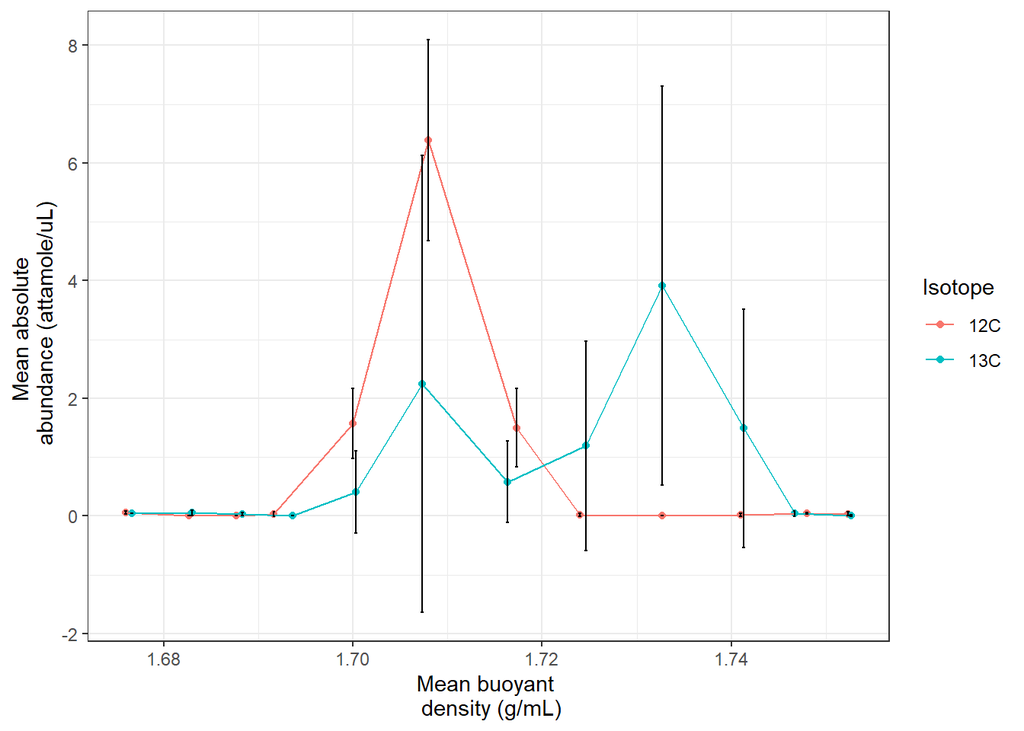

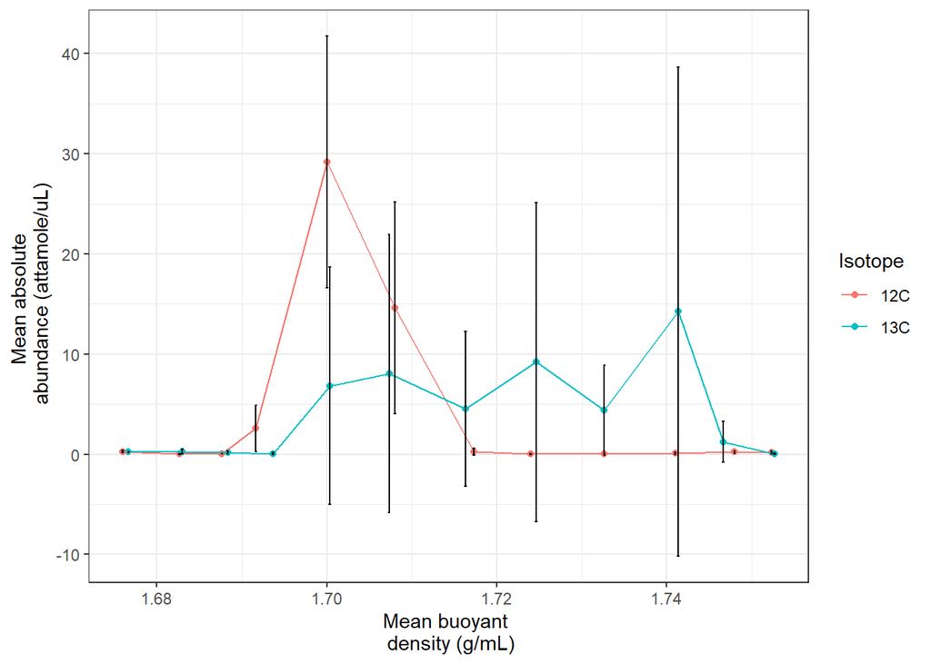

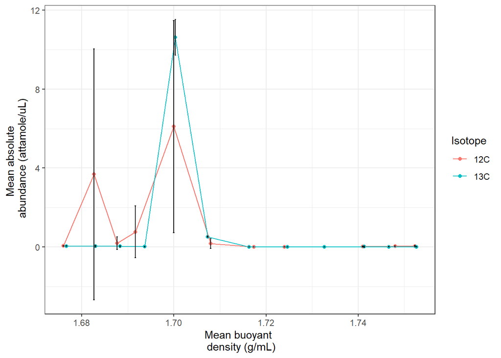